# Exercise 2 - Data Preparation

Ryan Wesslen

June 15, 2016

### Objective: Analyze the major presidential candidates Tweets

Rerun the the data (you can skip this if you still have the datasets open).

#### Step 1: Read in the data.

```r
#set your personal working directory if you're running as chunks
#setwd("~/Dropbox/fall-2016-pm-twitter-text/")

#remove one of the "." if you are running as chunks
raw.tweets <- read.csv("../datasets/pres-tweets.csv", stringsAsFactors = F)
source('../functions.R')
```

#### Step 2: Text Analysis with `quanteda`

We will use the `quanteda` package

```r
# updated for quanteda 0.9.9.50
library(quanteda); library(RColorBrewer)
```

To simplify our results, let’s only look at Tweets within the last six months (i.e. in 2016).

```r
tweets <- raw.tweets[substring(raw.tweets$estTime,1,4)=="2016",]
table(tweets$displayName)
```

```
##
##  Bernie Sanders Donald J. Trump Hillary Clinton        Ted Cruz
##            2429            2146            2279            1618
```

The `quanteda` package allows you to take a text (character) column and convert it into a DFM (data feature matrix, a generalization of a document-term matrix).

To do this, first, we have to use the `corpus` function to create our corpus. The corpus is data object that specializes in handling sparse (text) data.

```r
MyCorpus <- corpus(tweets$body)
```

You can retrieve any of the documents by using the following command:

```r
MyCorpus$documents[[1]][1]
```

```
## [1] "Congrats to Kappa Alpha Psi Inc. on 105 years of achievement. Very proud of my team and members @CSmithStrategy and @DannyDGlover. #J5"
```

```r
dfm <- dfm(MyCorpus,
           remove = c(stopwords("english"), "t.co", "https", "rt", "amp", "http", "t.c", "can", "u"),
           remove_numbers = TRUE,
           remove_punct = TRUE,
           remove_symbols = TRUE,
           ngrams=1L)
```

With our `dfm`, let’s view our top 25 terms in our corpus, using the `topfeatures()` function.

```r
topfeatures(dfm,25)
```

```
##             will          hillary            thank           people
##              871              738              619              595
##            trump               us             need        president
##              559              489              446              437
##            great            today             vote             make
##              426              425              418              405
##          america             just              new              now
##              404              397              391              372
##              get @realdonaldtrump             join          country
##              371              369              360              341
##              one         campaign        #cruzcrew       #gopdebate
##              339              338              272              266
##              win
##              255
```

Let’s create a word cloud for our top 100 terms.

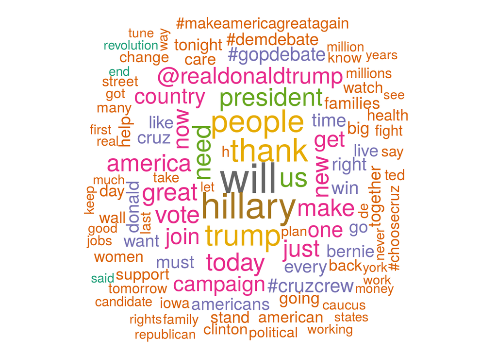

```r
textplot_wordcloud(dfm, scale=c(3.5, .75), colors=brewer.pal(8, "Dark2"),
     random.order = F, rot.per=0.1, max.words=100)
```

We can also reweight our plot by TF-IDF…

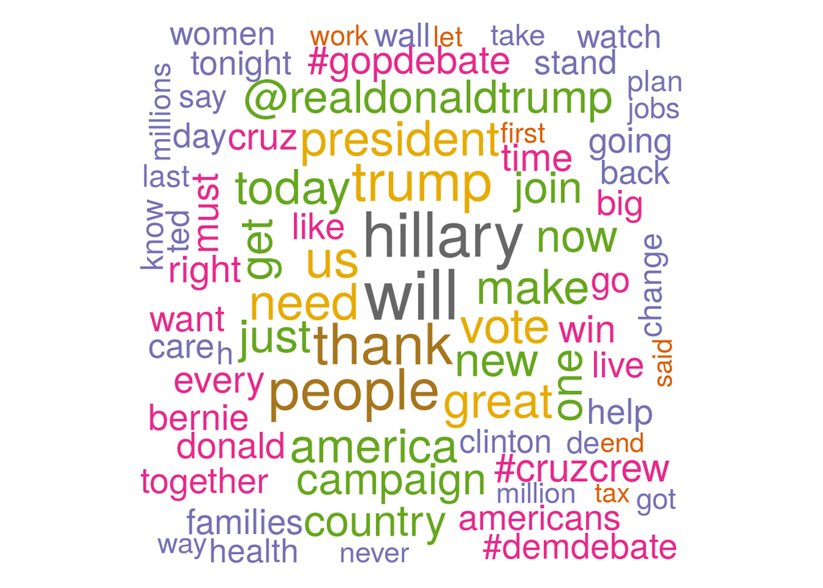

```r
textplot_wordcloud(tfidf(dfm), scale=c(3.5, .75), colors=brewer.pal(8, "Dark2"),
     random.order = F, rot.per=0.1, max.words=100)
```

### Step 3: Word Associations

Let’s now explore word associations.

```r
DTM <- as.DocumentTermMatrix(dfm)

library(tm)

# Word Associations
findAssocs(DTM, "cruz", 0.3)
```

```
## $cruz
##  ted
## 0.66
```

```r
findAssocs(DTM, "hillary", 0.2)
```

```
## $hillary
## crooked clinton
##    0.32    0.30
```

```r
findAssocs(DTM, "great", 0.2)
```

```
## $great
## america    make
##    0.30    0.25
```

Now let’s cluster the words…

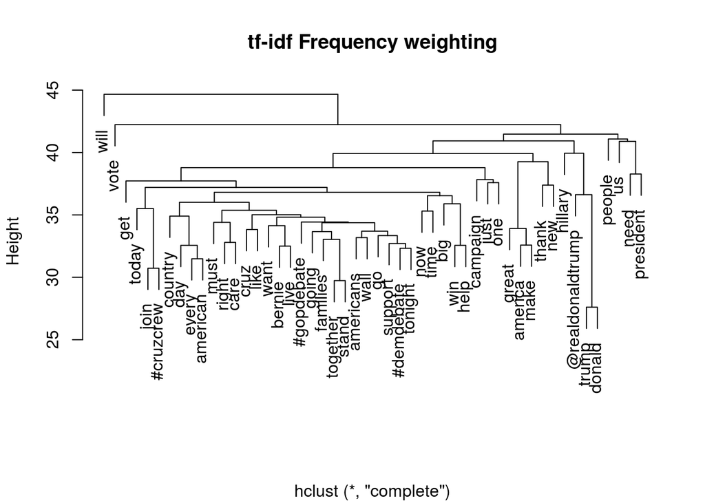

```r
twdfm <- dfm_trim(dfm, min_count=180)
wordDfm <- dfm_sort(dfm_weight(twdfm, "tfidf"))
wordDfm <- t(wordDfm)[1:50,]  # because transposed
wordDistMat <- dist(wordDfm)
wordCluster <- hclust(wordDistMat)
plot(wordCluster, xlab="", main="tf-idf Frequency weighting")
```

### Step 4: Aggregate by User

Maybe instead of keeping each document as a Tweet, we want to explore the Tweets and treat them as one document per Candidate. In this way, we would group (or aggregate) each of the candidates’ Tweets into one document. This will eliminate time but will help us explore the words’ of each candidate as a whole.

To do this, we must redo our `dfm` but use the `groups` option. Before that, we need to add the covariate `displayName` to our corpus. We will call it “Candidate”.

```r
docvars(MyCorpus, "Candidate") <- tweets$displayName

dfm <- dfm(MyCorpus,
           groups = "Candidate", # add in groups
           remove = c(stopwords("english"), "t.co", "https", "rt", "amp", "http", "t.c", "can", "u"),
           remove_numbers = TRUE,
           remove_punct = TRUE,
           remove_symbols = TRUE,
           ngrams=1L)
```

Now, let’s also explore the word clouds using the `comparison` option…

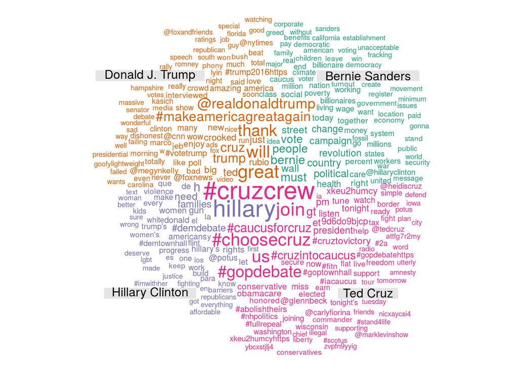

```r
textplot_wordcloud(dfm,
                   comparison = T, # add in comparison group
                   scale=c(2, .5), # scale from largest to smallest words
                   colors=brewer.pal(8, "Dark2"), # color by partition
                   random.order = F, # randomize order
                   rot.per=0, # proportion of words 90 degrees
                   title.size=1, # title labels
                   max.words=300)
```